# Measuring parental user experience with the NCMP letters

Updated Version for the Nottinghamshire Healthcare NHS Foundation Trust

M Cadek

2020-09-04

## Introduction

The following report shows the results of User Experience Questionnaire (Laugwitz et al., 2008). The measure was used as part of my PhD project in order to assess parental opinions regarding the National Child Measurement Programme (the NCMP) feedback letters measuring their child’s weight and height. Specifically, the project asked the question *“What are the opinions of parents or carers about the NCMP result letters?”*.

**Please note that this is a shorter version adapted for the purpose of illustrating my work as part of the interview for the data scientist position at Nottinghamshire Healthcare NHS Foundation Trust. This version utilised synthetic data (using the synthpop package) and the report does not show demographic variables.**

## The nature of this report

The focus was on overall experience with the letter as measured across several domains such as Attractiveness (overall impression), Dependability (feeling in control), Efficiency (effort required to use), Novelty (is it innovative or creative), Perspicuity (accessibility and ease of understanding), Stimulation (is it exciting or motivating) (Schrepp et al., 2014).

Conceptually, the user experience model was expected to be affected by the following explanatory variables presented in the DAG (Directed acyclic graph) below.

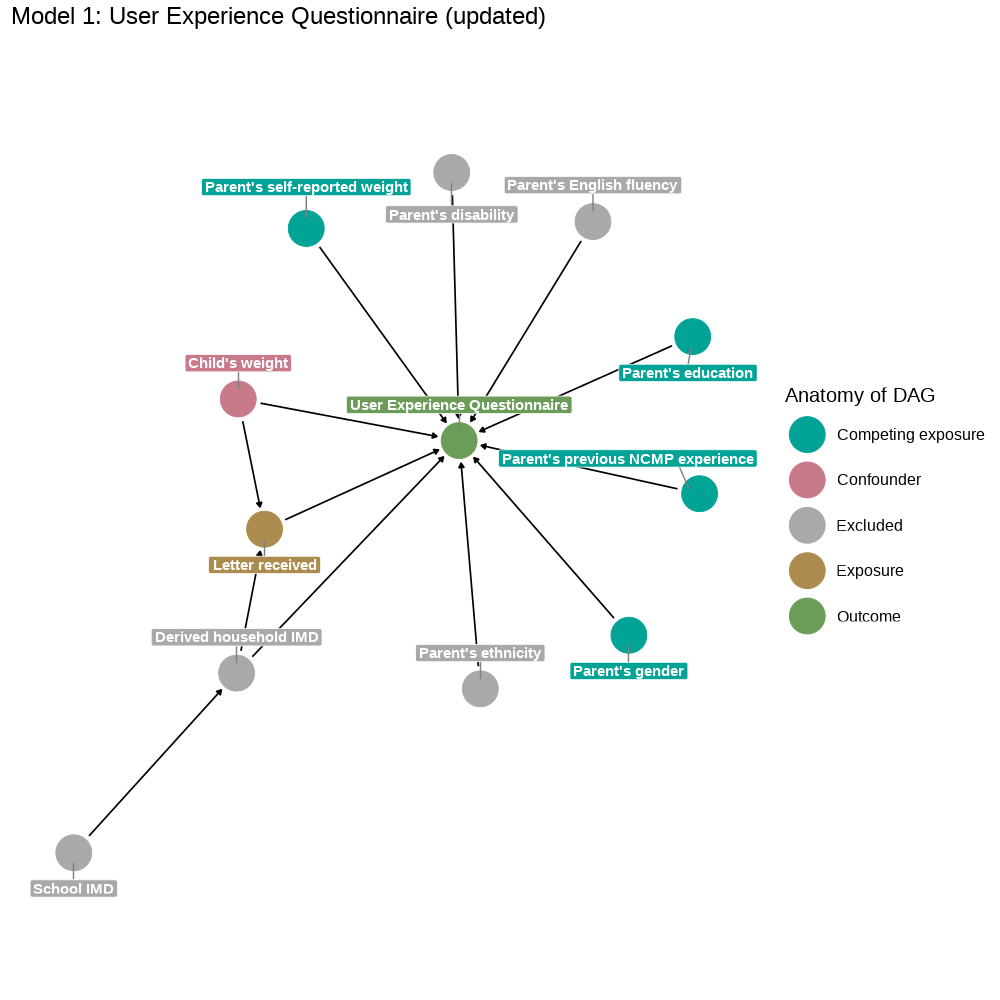

DAG - UEQ

## Assessing the correlation structure

The correlation structure of all variables was assessed as part of constructing the models focusing on interaction with the letter, and user experience. The matrix was also used to understand the variables and decide which to include. As most variables were categorical, a heterogeneous correlation matrix was computed using the “hetcor” function from the “polycor” package (Fox, 2019). The function uses Pearson correlation on numeric variables, but polyserial if variables are numeric and ordinal, or polychoric when variables are ordinal. The method was applied to obtain a correlation matrix between all outcome and exploratory variables. During the computation process, some cells were adjusted for 0 values using the correction for continuity. The matrix was developed on 86 participants who had non-missing values.

To decide which variables, I should exclude from further analyses, I have used the criteria of r ≤ 0.20 or r ≥ -0.20 while not being correlated with more than one outcome variable (y > 1).

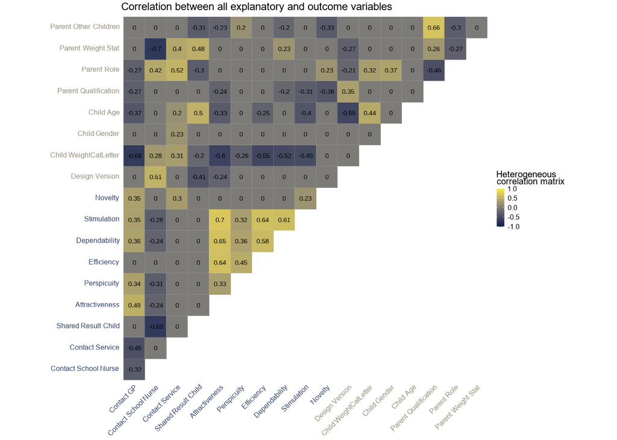

Correlation

## Variable coercion and visualisation

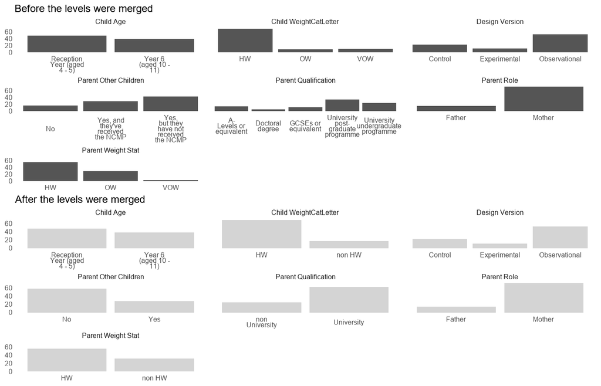

Collapssing the levels

## Findings regarding the UEQ - Attractiveness

The first outcome variable assessed in the UEQ was attractiveness which measured the overall impression of the product (Schrepp, 2019, p. 2).

### Predictors

The visual representation below shows plots with the outcome variable (UEQ: Attractiveness) being regressed on each explanatory variable.

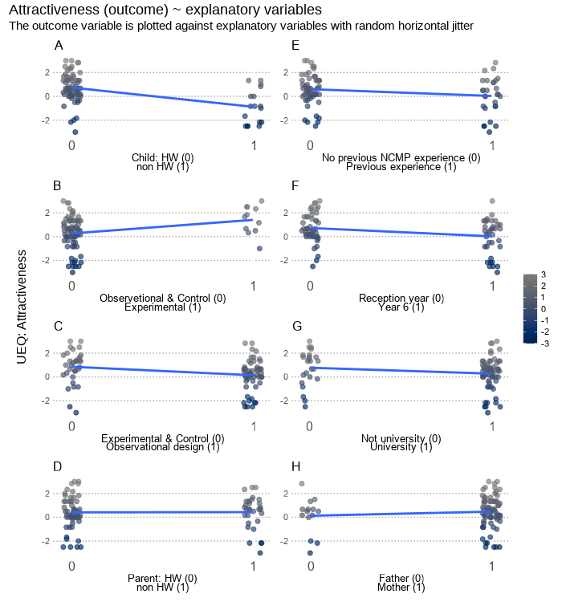

### Models

Seven models were tested against each other and the best performing model was selected (with explanatory variables included hierarchically). Table below shows the statistics of each model and the corresponding explanatory variable on the outcome variable.

| model | r.squared | adj.r.squared | sigma | statistic | p.value | df | logLik | AIC | BIC | deviance | df.residual | nobs |
| --- | --- | --- | --- | --- | --- | --- | --- | --- | --- | --- | --- | --- |
| 1 | 0.22 | 0.21 | 1.2 | 23.8 | 0 | 1 | -139 | 283 | 290 | 126 | 84 | 86 |
| 2 | 0.30 | 0.28 | 1.2 | 12.0 | 0 | 3 | -134 | 277 | 290 | 113 | 82 | 86 |
| 3 | 0.31 | 0.27 | 1.2 | 9.0 | 0 | 4 | -134 | 279 | 294 | 112 | 81 | 86 |
| 4 | 0.33 | 0.28 | 1.2 | 7.8 | 0 | 5 | -132 | 279 | 296 | 109 | 80 | 86 |
| 5 | 0.36 | 0.31 | 1.1 | 7.5 | 0 | 6 | -130 | 276 | 296 | 104 | 79 | 86 |
| 6 | 0.37 | 0.31 | 1.1 | 6.4 | 0 | 7 | -130 | 277 | 300 | 103 | 78 | 86 |
| 7 | 0.37 | 0.31 | 1.1 | 5.7 | 0 | 8 | -129 | 279 | 303 | 102 | 77 | 86 |

The second model was also favoured given the significant statistics as presented in table below as the model seemed to be improved with the inclusion of an additional explanatory variable.

| model | res.df | rss | df | sumsq | p.value |
| --- | --- | --- | --- | --- | --- |
| 1 | 84 | 126.35 |  |  |  |
| 2 | 82 | 112.77 | 2 | 13.58 | 0.01 |
| 3 | 81 | 112.39 | 1 | 0.38 | 0.59 |
| 4 | 80 | 109.24 | 1 | 3.14 | 0.12 |
| 5 | 79 | 103.51 | 1 | 5.74 | 0.04 |
| 6 | 78 | 102.82 | 1 | 0.69 | 0.47 |
| 7 | 77 | 102.02 | 1 | 0.79 | 0.44 |

### Selecting the final model

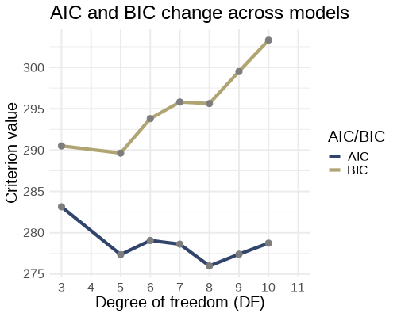

Once the model was selected number of diagnostics were performed to measure the model (Figure below). Residual plots showed no indication of unusual patterns; however, few outliers were identified in the model.

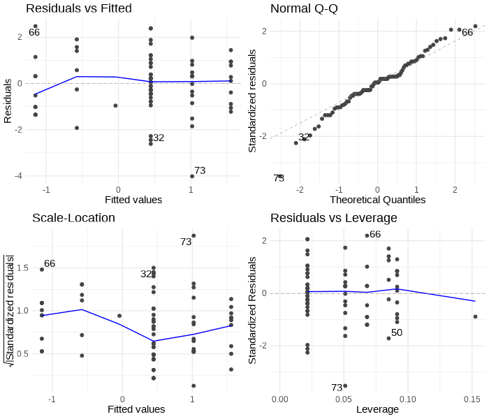

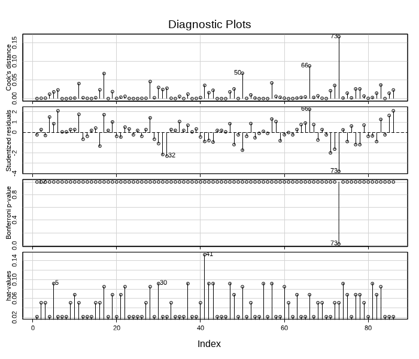

### The Final model

| term | estimate | std.error | statistic | p.value | conf_low | conf_upper |
| --- | --- | --- | --- | --- | --- | --- |
| (Intercept) | 1.00 | 0.27 | 3.7 | 0.00 | 0.46 | 1.55 |
| Child WeightCatLetter non HW | -1.59 | 0.32 | -4.9 | 0.00 | -2.23 | -0.95 |
| Design VersionExperimental | 0.55 | 0.44 | 1.2 | 0.22 | -0.33 | 1.43 |
| Design VersionObservational | -0.56 | 0.31 | -1.8 | 0.07 | -1.17 | 0.05 |

The model (table below) also explained 28 % of the variance in the data which is fairly reasonable given the poor sample size.

| r.squared | adj.r.squared | sigma | statistic | p.value | df | logLik | AIC | BIC | deviance | df.residual | nobs |
| --- | --- | --- | --- | --- | --- | --- | --- | --- | --- | --- | --- |
| 0.3 | 0.28 | 1.2 | 12 | 0 | 3 | -133 | 275 | 287 | 113 | 81 | 85 |

### Visualising the final model

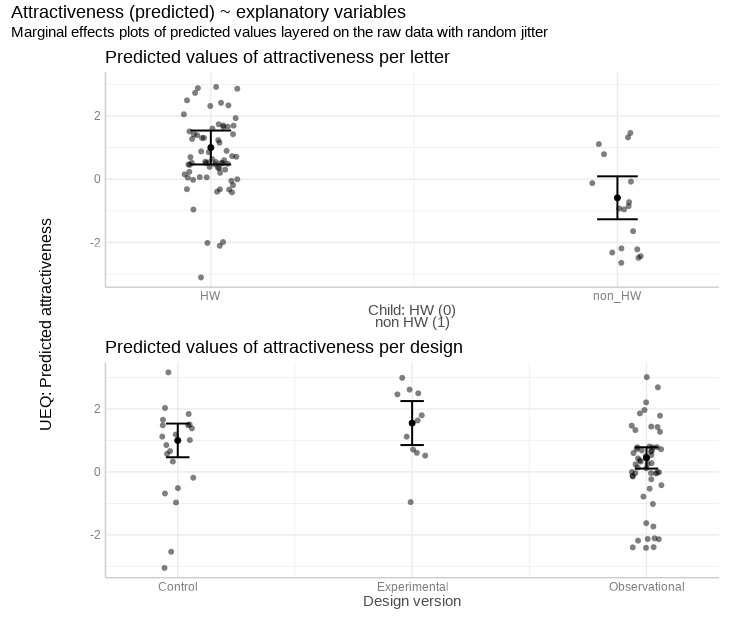